# Mesures physiologiques des émotions dans la pratique des jeux vidéos. Expérience LM

Godefroy Clair

16 juillet 2015

subtitle : “Première approche : statistique descriptive”

Travail préliminaire sur les données transmises par Viviane Gal concernant la mesure physiologique d’*un* joueur lors d’*une* expérience. Cette expérience a eu lieu le 6 mars 2014. Les mesures ont été réalisées par 4 capteurs qui concernent respectivement la respiration, l’activité électrodermale, la température et la fréquence cardiaque.

Trois étapes : 1. transformation des données 2. quelques statistiques descriptives 3. Représentations graphiques des données

[output not shown]

### 1. Tranformation des données (nettoyage, mises en forme, décomposition, marquage)

chargement des données au format numérique (sauf 1ère colonne au format “date”, POSIX)

Dimension du tableau de données : 48719 x 6

```
[1] "       date           respiration   activite.electrodermale   temperature   frequence.cardiaque"
[2] "-------------------- ------------  ------------------------  ------------  --------------------"
[3] "2014-03-06 15:19:29        -18.67                   -39.114        22.923                    84"
[4] "2014-03-06 15:19:29        -18.67                   -39.114        22.923                    84"
[5] "2014-03-06 15:19:29        -18.67                   -39.114        22.923                    84"
[6] "2014-03-06 15:19:29        -18.67                   -39.114        22.923                    84"
[7] "2014-03-06 15:19:29        -18.67                   -39.114        22.923                    84"
[8] "2014-03-06 15:19:29        -18.67                   -39.114        22.923                    84"
```

Y a-t-il des données manquantes ?

```
[1] date                    respiration             activite.electrodermale
[4] temperature             frequence.cardiaque     quart.temps
<0 rows> (or 0-length row.names)
```

### 2. statistique descriptive

Quelques statistiques pour résumer les données

|  | date | respiration | activite.electrodermale | temperature | frequence.cardiaque | quart.temps |
| --- | --- | --- | --- | --- | --- | --- |
|  | Min. :2014-03-06 15:19:29 | Min. :-18.67 | Min. :-40.16 | Min. :22.90 | Min. :75.00 | 1er quart :12180 |
|  | 1st Qu.:2014-03-06 15:25:50 | 1st Qu.:-18.67 | 1st Qu.:-38.91 | 1st Qu.:22.91 | 1st Qu.:81.00 | 2eme quart:12180 |
|  | Median :2014-03-06 15:32:10 | Median :-18.67 | Median :-38.23 | Median :22.94 | Median :83.00 | 3eme quart:12179 |
|  | Mean :2014-03-06 15:32:10 | Mean :-18.64 | Mean :-37.15 | Mean :22.95 | Mean :82.73 | 4eme quart:12180 |
|  | 3rd Qu.:2014-03-06 15:38:31 | 3rd Qu.:-18.67 | 3rd Qu.:-35.06 | 3rd Qu.:22.97 | 3rd Qu.:85.00 | NA |
|  | Max. :2014-03-06 15:44:52 | Max. :-16.45 | Max. :-30.28 | Max. :23.06 | Max. :93.00 | NA |

Déviation standard par variable:

```
            respiration activite.electrodermale             temperature
             0.15500086              2.41540109              0.04665916
    frequence.cardiaque
             2.96815499
```

### 3. représentations graphiques des données

#### a) Quelques histogrammes

##### Pour la respiration :

##### Pour l’activité electrodermale :

##### Pour la température :

##### Pour la fréquence cardiaque :

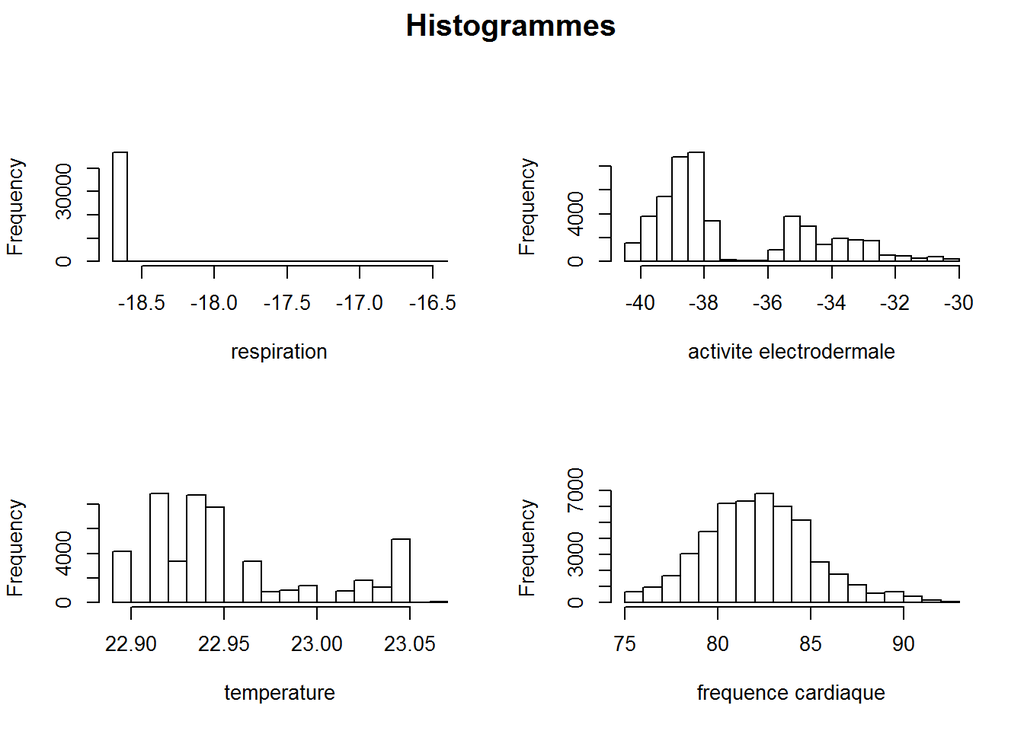

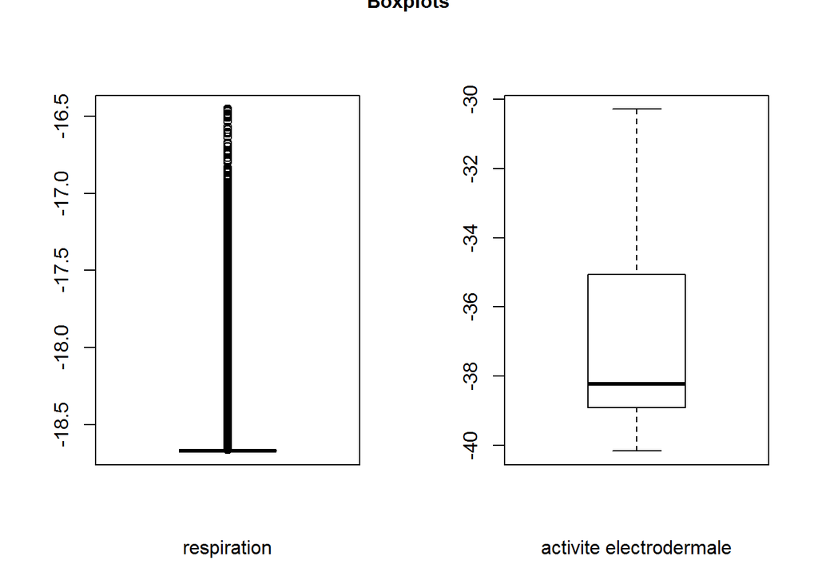

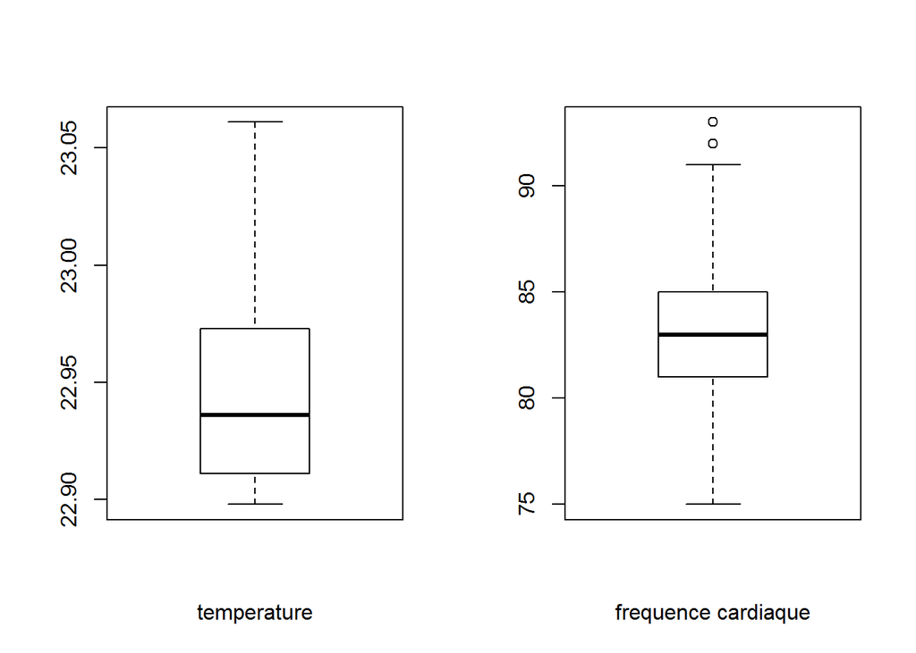

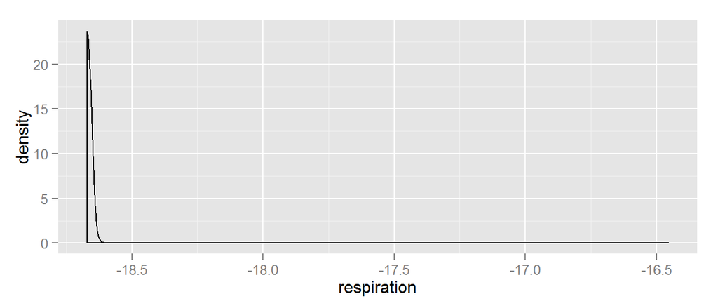

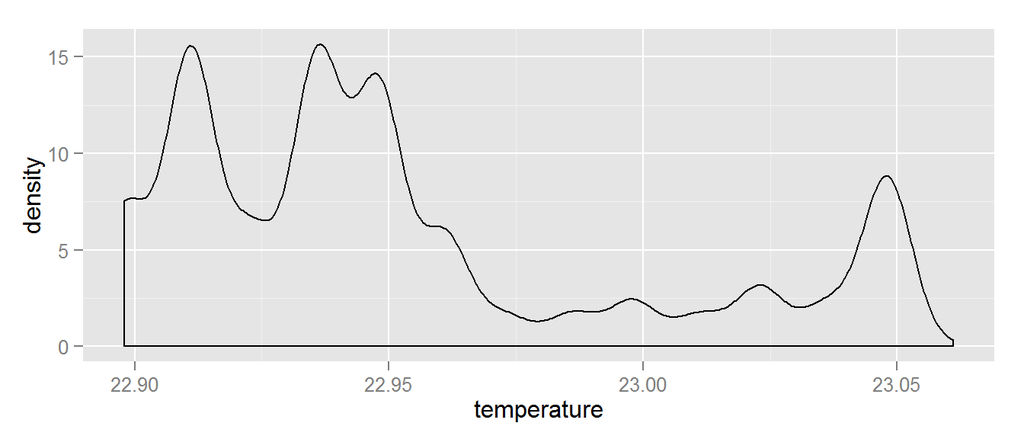

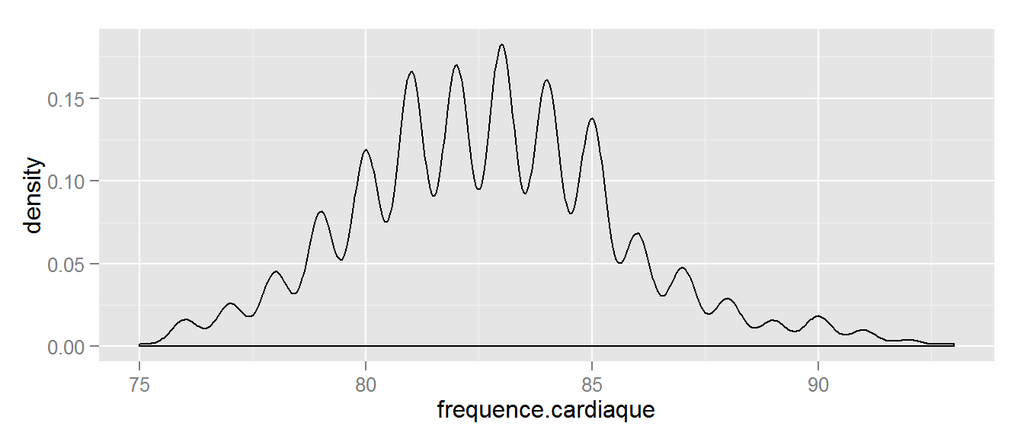

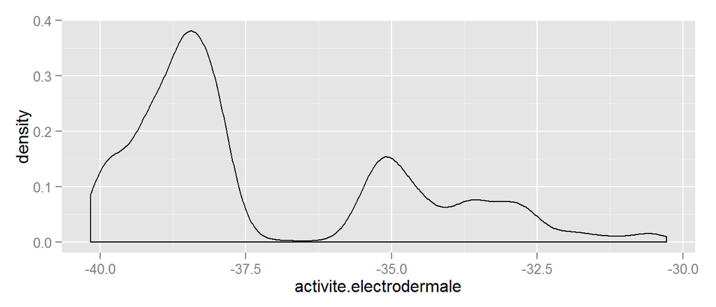

[figure not shown]

frequence respiration, activité ED & séparées par frequence cardiaque :

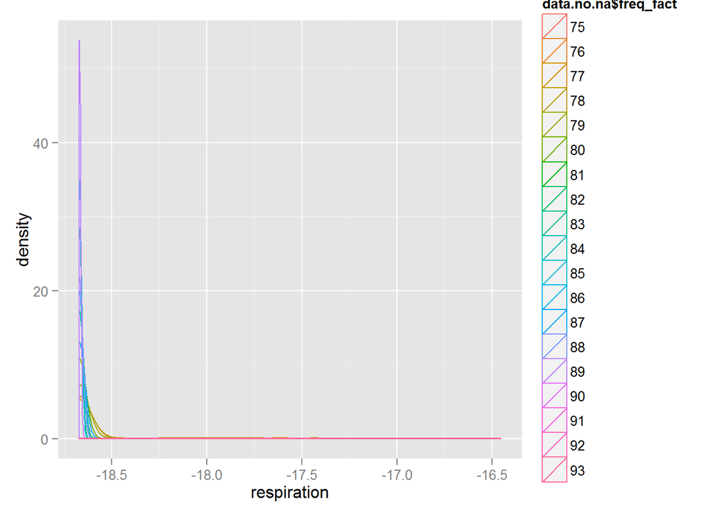

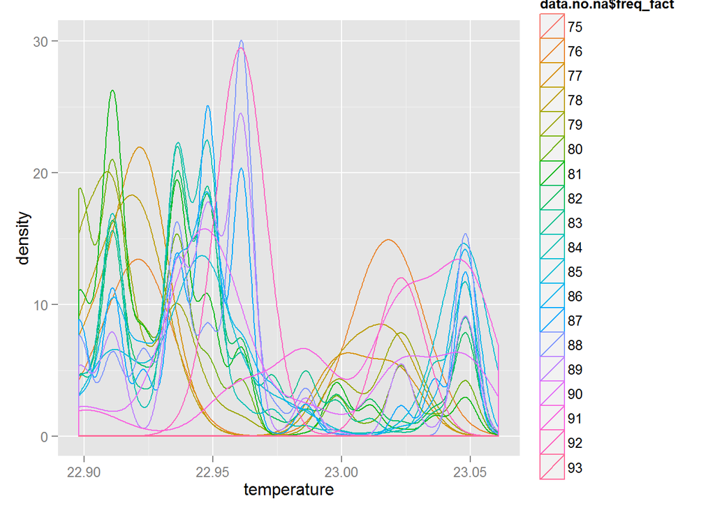

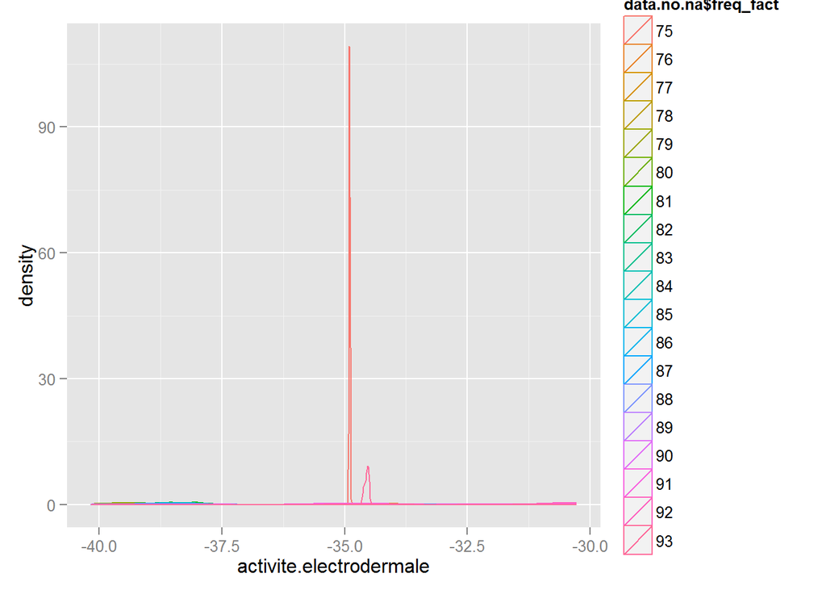

Nuages de points par pair de variables (pour les données de type réels)

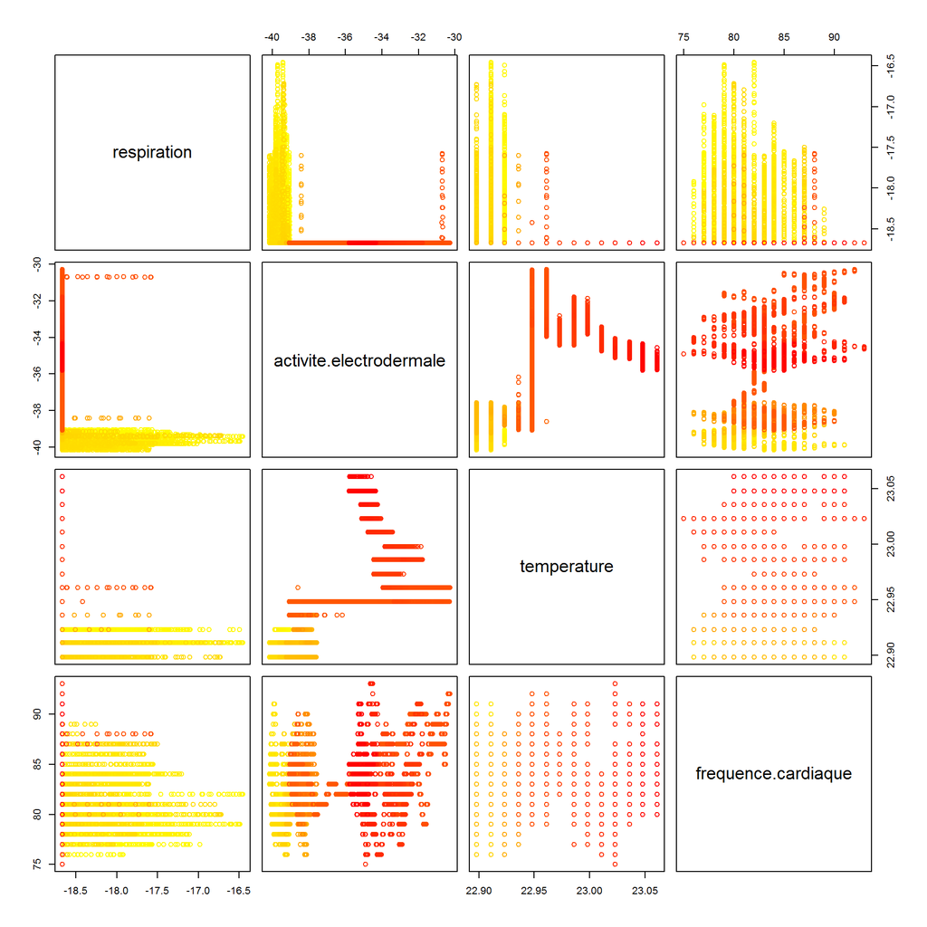

Nuage de points avec variation de l’intensité de la couleur en fonction de la densité:

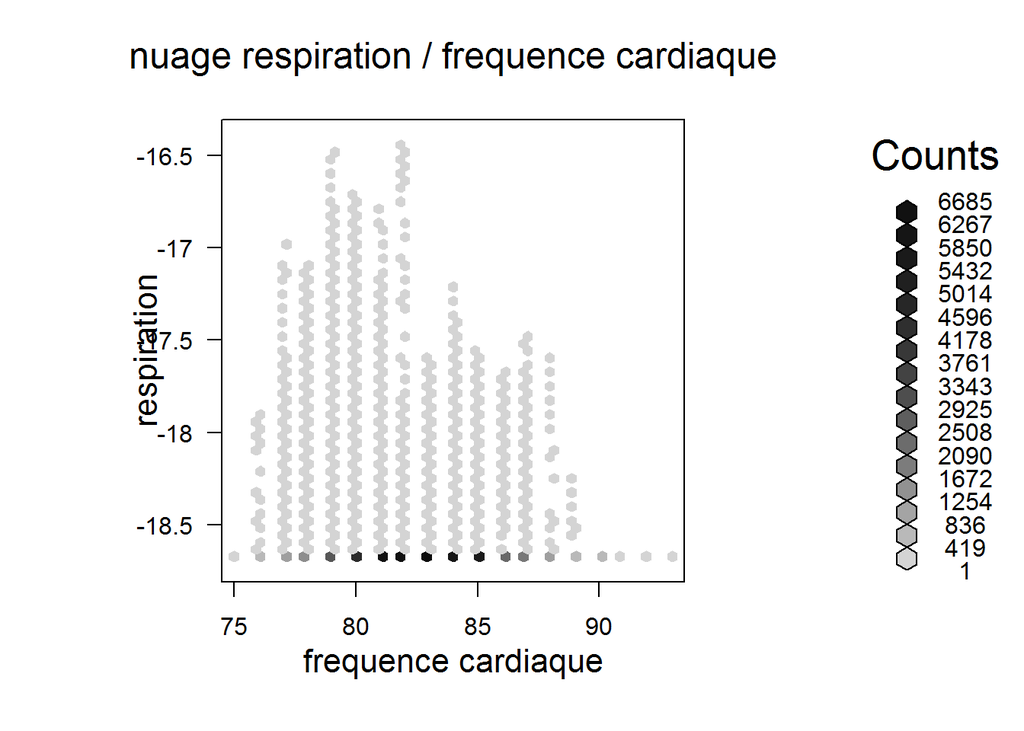

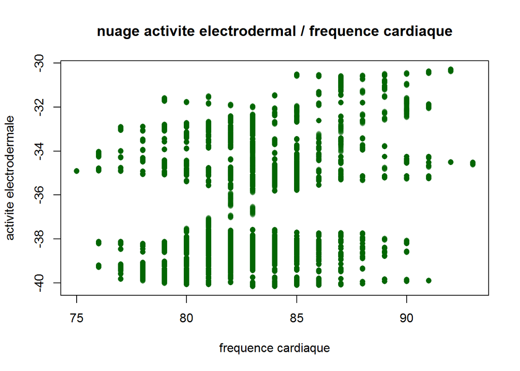

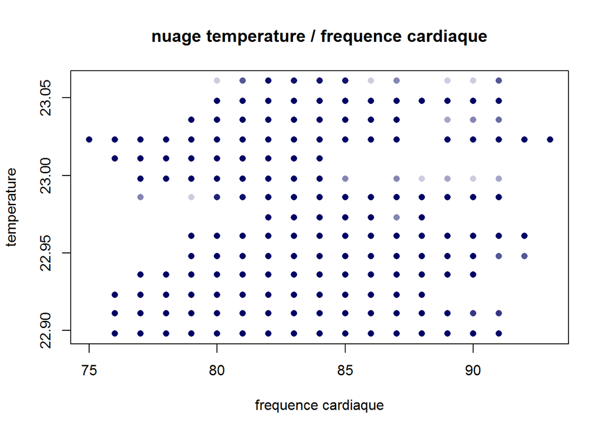

Représentation des données en 3D

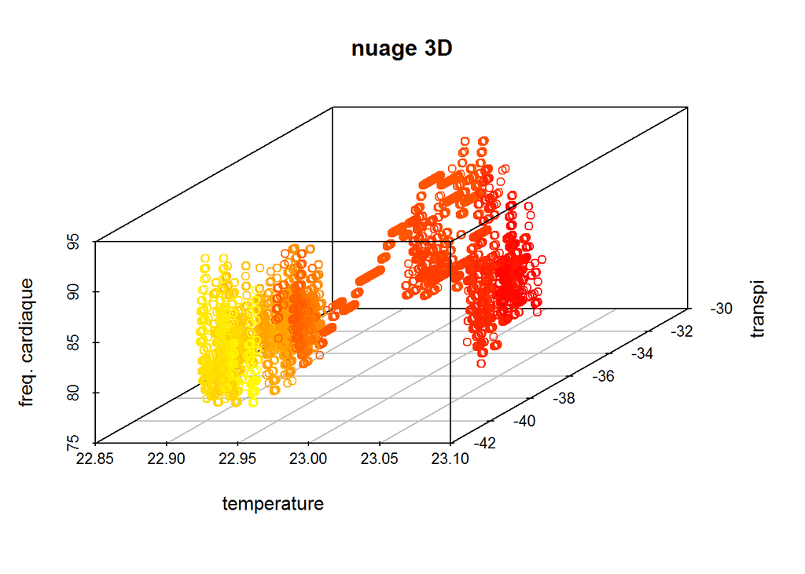

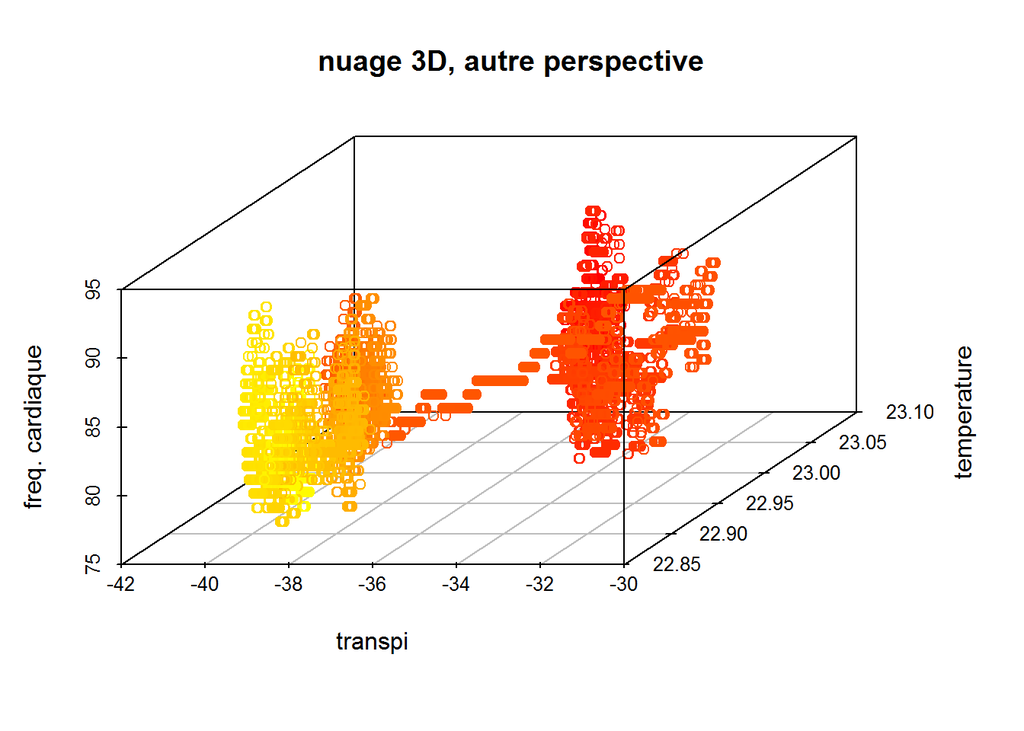

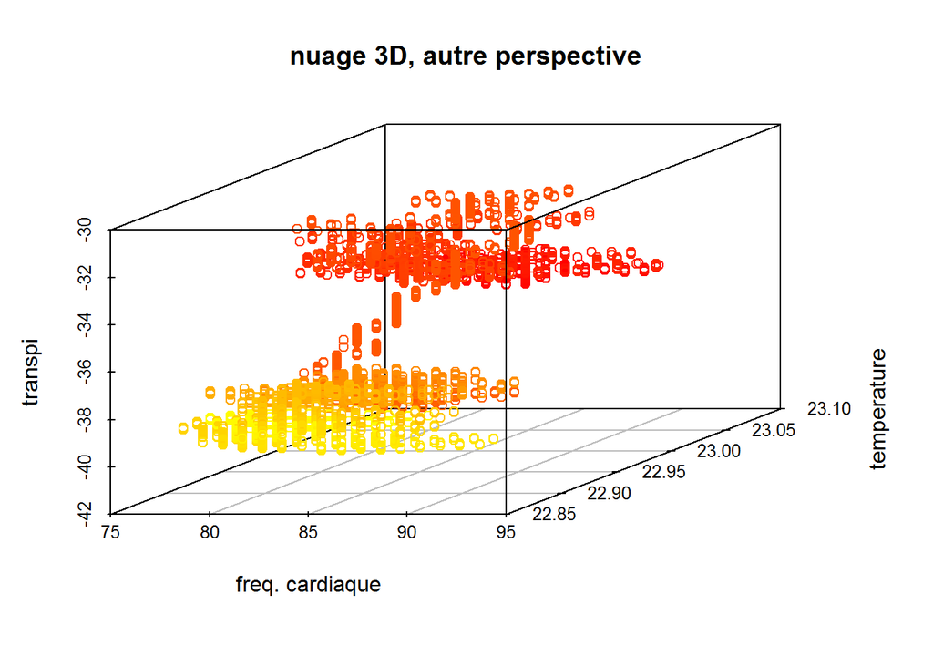

4. Première fouille des données
1. Dendogramme

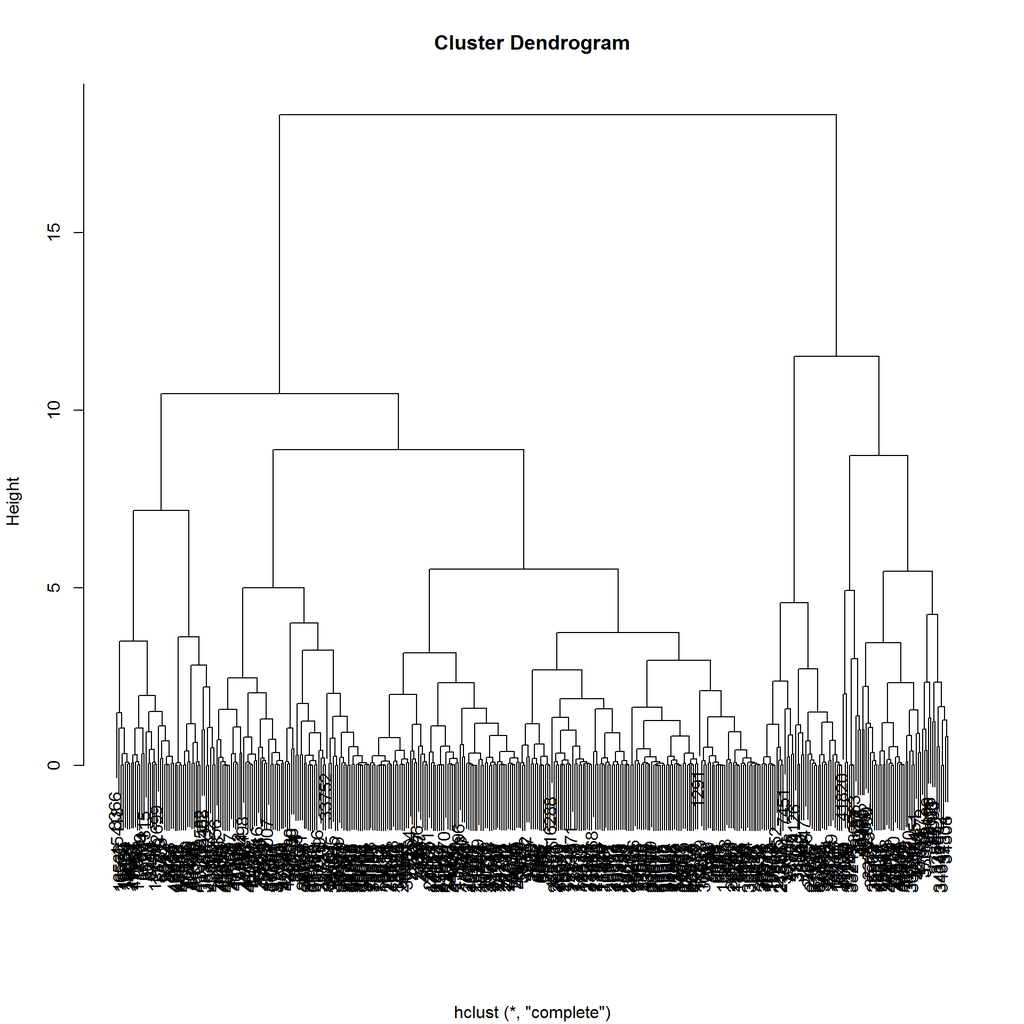

2. SOM (les neurones sont représentés dans l’ordre croissant de leur index de gauche à droite, de bas en haut)

1ère simulation

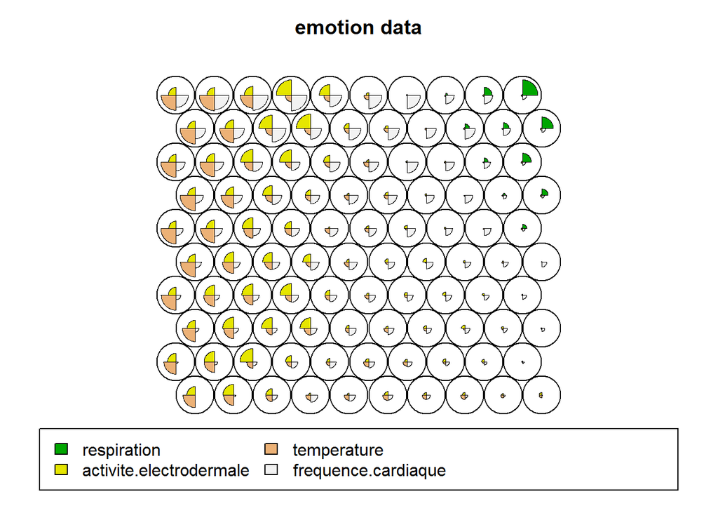

```
##
##    1    2    4    5    6    7    8    9   10   11   12   13   14   15   16
##  368  286 1013  761  424 1004  614  555  543  526  260  134   90  564  403
##   17   18   19   20   21   22   23   24   25   26   27   28   29   30   31
## 1601  265  280  640  767  334  620  577  797  821  357  679  675 1124  629
##   32   33   34   35   36   37   38   39   40   41   42   43   44   45   46
##  304  344  483   68 1027  282  518  782 1237  768  321  613  108  942  215
##   47   48   49   50   51   52   53   55   56   57   58   59   60   61   62
##  222  812  659  413  668  500  538  443 1477  449  687  428  199  796   64
##   63   65   66   67   68   69   70   71   72   73   74   76   77   78   79
##  618 1168 1068  492  605  251  198 1327  467  241  202  711  439  635  162
##   80   81   82   83   84   86   87   88   89   90   91   92   93   94   95
##  193  611  268  489  497  682  461   74  153  120  278  245  317  148  640
##   96   97   98   99  100
##  390  157  146  132   56
```

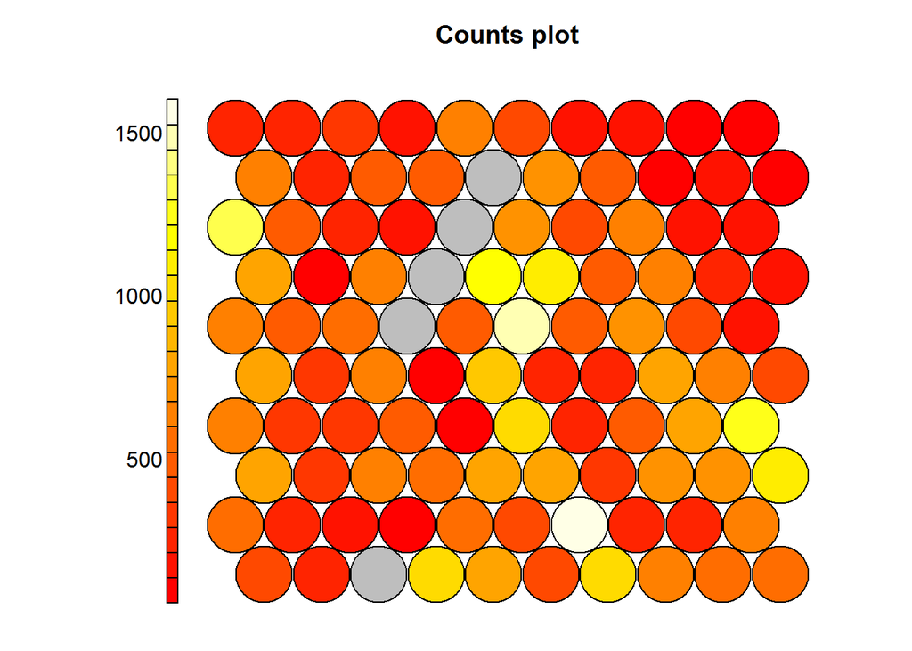

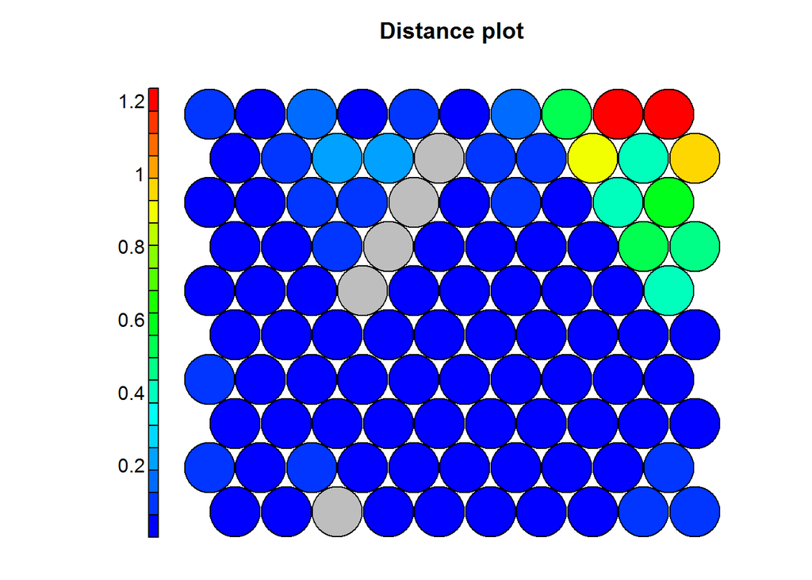

2nde simulation

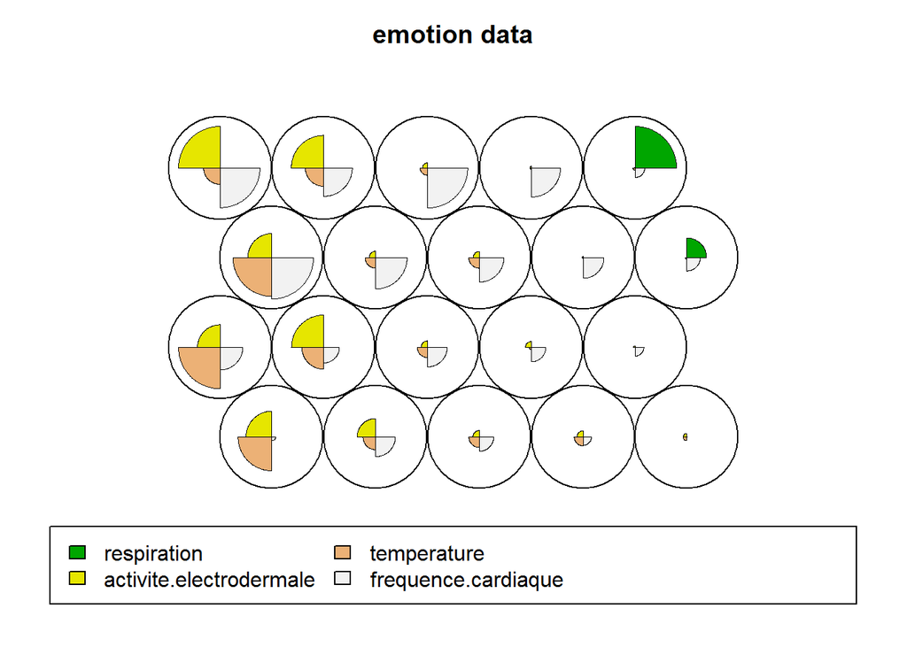

```
##
##    1    2    3    4    5    6    7    8    9   10   11   12   13   14   15
## 2660  244 4530 2062 1826 5372 3995 3052 3718 4063 1164 1521 4823 2610  969
##   16   17   18   19   20
## 1208 1872  981 1632  417
```

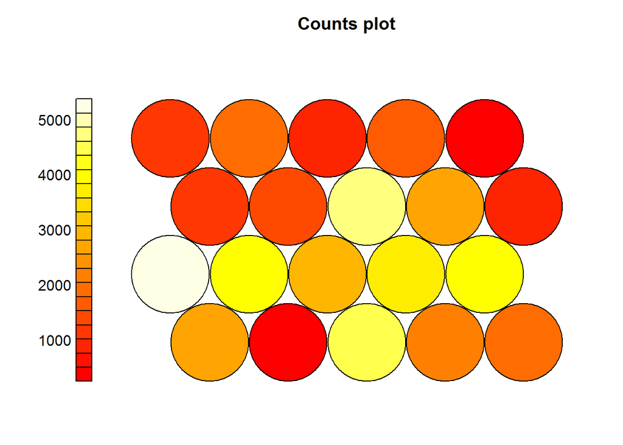

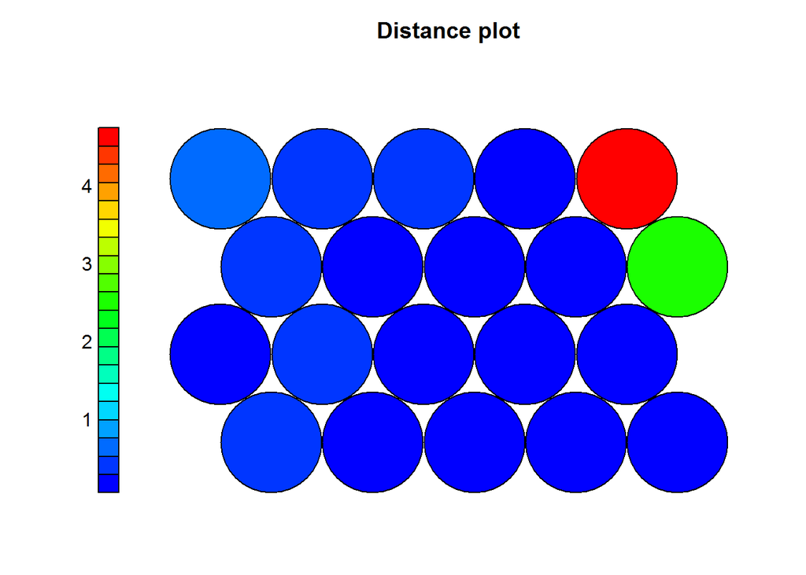

Regroupement des données

1. par neurone

Voir les fichiers “periodes_captées_par_neurone.txt” et “periodes_sup_ 3 _sec_captées_par_neurone“”

2. par groupes de neurones

Pou AB (seeds 7) :